# Final project

## DISCUSSION

So to answer the ultimate question of this project, there clearly exists a gender gap interms of income but as female counterparts pursue higher education than their male counterparts, the gender gap dissolves.

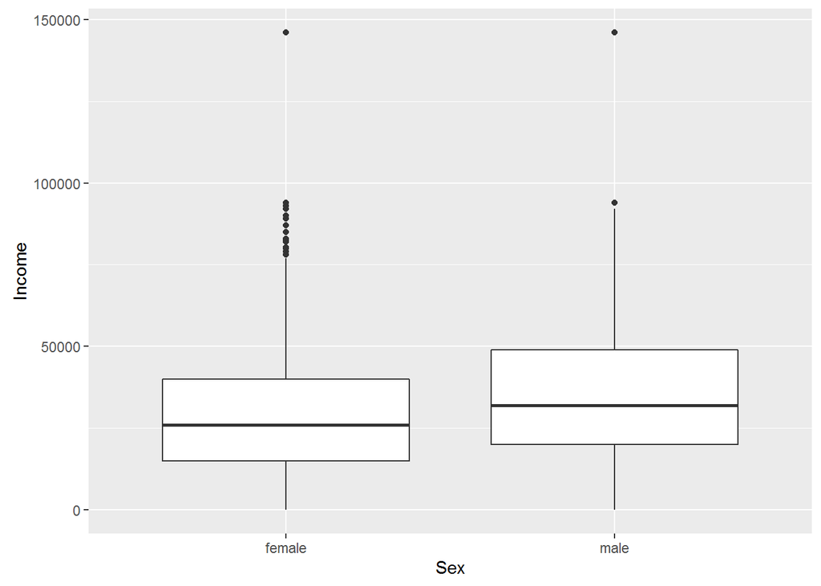

```r
# The below boxplot clearly shows that males earn higher than females.
qplot(x = GENDER,
      y = RANGE.INCM.LAST.YR, geom = "boxplot", data = nlsy,
      xlab = "Sex", ylab = "Income")
```

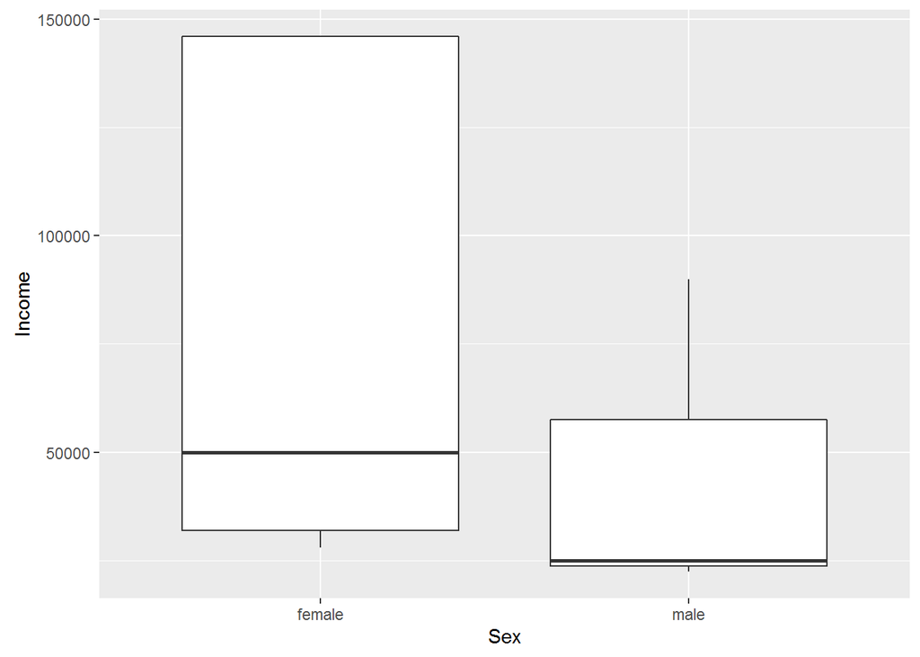

```r
phD.income <- subset(nlsy, DEG.RCVD == "PhD", select = c(5, 23))

# The below shown is the boxplot of individuals who did a PhD and clearly it can be seen that the average earnings of females is higher than that of males.

qplot(x = GENDER,
      y = RANGE.INCM.LAST.YR, geom = "boxplot", data = phD.income,
      xlab = "Sex", ylab = "Income")
```

Hence the assertion ‘Is there a significant difference in income between men and women?’, is positive and through my analysis it is also statistically supported. And this difference in income between the genders definitely depends on educational qualifications of the individual.

One main limitation I faced is the lack of population percentage of men and women in differnct regions from where the survey respondent come from. Some areas or industries might have more males than females and because of higher strength, the mean income between the two might not be fair to compare. Apart from this factor, the models that I developed is believable and also supports the current gender bias.

From the level of analysis I’ve made in this project, I can very well say that I’m confident about my findings and I do believe in my inferences. For this reason, I’m confident enough to present my findings to the policy makers.